# Data Science Capstone - Milestone Report

Marko Intihar

2/2/2021

# Problem

The main goal of project is to build a language prediction model application using Shiny App. The user of the app will input a text of one, two, three or maybe more words, and model must predict the next logical word for inputted text. This is done using text corpus and language prediction model.

# Data

For this project we are using 3 different english language corpus sources:

- **news** (corpus containing news)
- **twitter** (corpus containing twitter data)
- **blogs** (corpus containing blogs)

The data was downloaded from the link provided, it was unzipped and imported into R. Original corpus data is different in size, since:

- news corpus consists of around 1 million lines
- twitter corpus consists of around 2.3 million lines
- and blogs corpus has around 900 thousand lines

Lines are different in size with respect to number of words and characters in each line.

In order to build a model we first has to apply some data cleaning and also some data exploration.

## Data cleaning

After all three corpus data were imported into R session, the data cleaning was applied. For this operation we have used R’s library called **tm**, which already includes many functions for tex mining. Corpus cleaning consists of given steps:

- convert raw text to character vectors
- remove punctuation from the text
- convert all text to lower case
- remove stop words (english language stop words like: the, he, have, I, etc.)
- remove profanity words (bad words)
- remove additional white spaces from the text
- create stemmed text (text stemming is the process of reducing words to their word stem)

Since we do not have unlimited computer power in sense of CPU and RAM, we have decided to create sample data for each corpus. Sample corpus must represent the original data set. Sample corpus is used for data exploration and further for building language prediction model.

After data cleaning step we have created corpus samples, for each corpus 100 thousand lines were randomly selected, so the samples represent the given percentage of the original data (if we count lines):

- news sample - around 10% of original lines
- twitter sample - around 5% of original lines
- blogs sample - around 12% of original lines

### Data preparation

Next step of the given analysis involves data preparation. In this step the first part covers:

- building term document matrix (TDM)
- then building term frequency vector (TFV)
- and converting TFV to data frame
- and calculating word frequencies using TFV data frame

Word frequencies represent the occurrence or number of times each word appears in the given corpus. Word frequencies are a main tool for building our prediction model in the further steps.

Also for prediction model we must create so called **n-grams**. In the context of given problem a *n-gram* is a sequence of **n** words that appear together in the observed text. They build a context of given text and we can count how many times certain words appear together. n-grams will be a baseline for our word prediction algorithm. We can use different values for **n**, such as:

- $n=1$ - uni-grams (one word)
- $n=2$ - bi-grams (two words)
- $n=3$ - three-grams (three words)
- $n=4$ - four-grams (four words)
- and so on …

To build different *n-grams* we used R’s library *RWeka*, which provides a function called **NGramTokenizer** that does do the job. Mentioned function and all the other function from selected package come from application called *Weka*, which is mainly used for machine learning purposes.

# Exploratory Data Analysis

Exploratory data analysis or EDA was applied on the sampled data. Since generated samples are quite big, we believe that applying exploration on samples should not be an issue. In the EDA step we were trying to answer few given questions.

Let’s first do some basic counts regarding each corpus.

```r
table.summaries %>%
  kbl() %>%
  kable_styling()
```

| corpus | object size MB | line counts | word counts | character counts |
| --- | --- | --- | --- | --- |
| news | 205.8119 | 1010242 | 19267081 | 104286427 |
| twitter | 167.1053 | 2360148 | 16199450 | 80561906 |
| blogs | 210.1600 | 899288 | 18859320 | 97934748 |

Object size is reported in MB (raw corpus before imported into R). Line count, word count and character counts are reported for corpus after being cleaned.

### Word frequencies

The first question we were trying to find an answer for, is:

*“Some words are more frequent than others, what are the distributions of word frequencies?”*

Here we are using word frequencies and trying to show the most frequent words for each corpus.

So the distribution of top 50 words in the **news corpus** is:

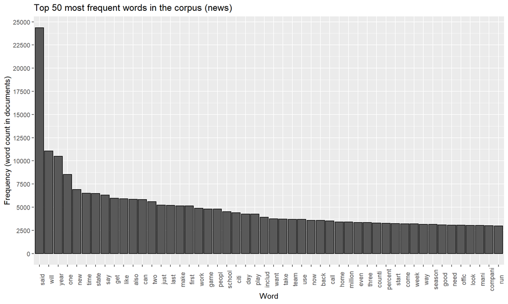

```r
news.TFV.df.sum %>%
  filter(rank_word <= 50) %>%
  mutate(word = fct_inorder(f = word)) %>%
  ggplot(aes(x = word, y = frequency)) +
  geom_col(color = "black") +
  scale_y_continuous(breaks = seq(0,25000,2500)) +
  xlab("Word") +
  ylab("Frequency (word count in documents)") +
  ggtitle("Top 50 most frequent words in the corpus (news)") +
  theme(axis.text.x = element_text(angle = 90))
```

Also we can create a **word cloud** for news corpus showing top 100 words (font size of each word is depends on word frequency in the corpus):

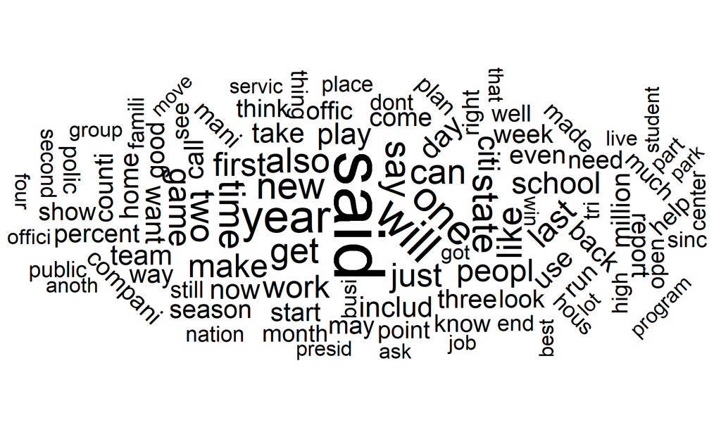

```r
set.seed(135) # randomness in positioning labels in the cloud
news.TFV.df.sum %>%
  mutate(angle = 90 * sample(c(0,1), n(), replace = T, prob = c(0.7, 0.3))) %>%
  mutate(angle1 = 45 * sample(c(-2:2), n(), replace = T, prob = c(1,1,4,1,1))) %>%
  filter(rank_word <= 100) %>%
  ggplot(aes(label = word,
             size = frequency,
             angle = angle1)) +
  geom_text_wordcloud() +
  scale_size_area(max_size = 25) +
  theme_minimal()
```

We can see that in the news corpus the top most three frequent words are: “said”, “will”, “year”.

Now lets show the distribution of top 50 words in the **twitter corpus**:

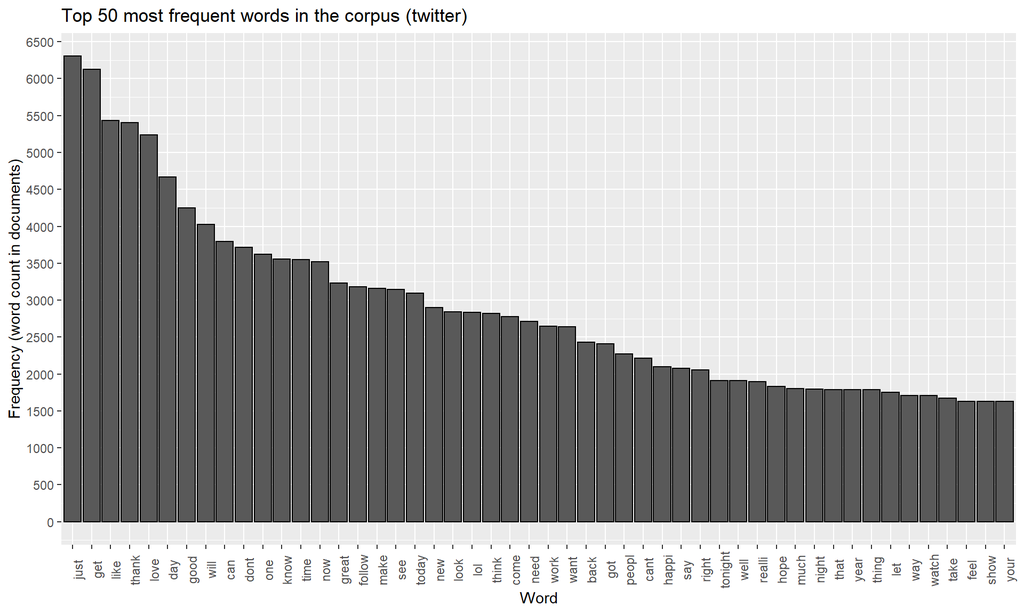

```r
twit.TFV.df.sum %>%
  filter(rank_word <= 50) %>%
  mutate(word = fct_inorder(f = word)) %>%
  ggplot(aes(x = word, y = frequency)) +
  geom_col(color = "black") +
  scale_y_continuous(breaks = seq(0,10000,500)) +
  xlab("Word") +
  ylab("Frequency (word count in documents)") +
  ggtitle("Top 50 most frequent words in the corpus (twitter)") +
  theme(axis.text.x = element_text(angle = 90))
```

And word cloud for top 100 words:

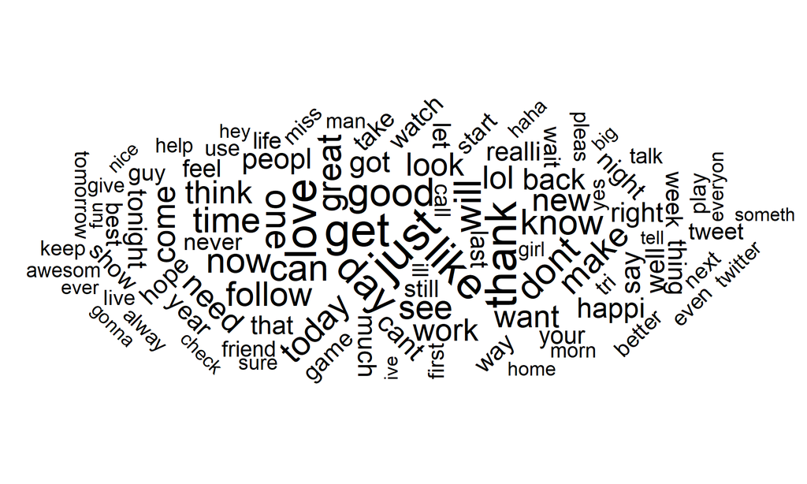

```r
set.seed(135) # randomness in positioning labels in the cloud
twit.TFV.df.sum %>%
  mutate(angle = 90 * sample(c(0,1), n(), replace = T, prob = c(0.7, 0.3))) %>%
  mutate(angle1 = 45 * sample(c(-2:2), n(), replace = T, prob = c(1,1,4,1,1))) %>%
  filter(rank_word <= 100) %>%
  ggplot(aes(label = word,
             size = frequency,
             angle = angle1)) +
  geom_text_wordcloud() +
  scale_size_area(max_size = 15) +
  theme_minimal()
```

In the twitter corpus the top most three frequent words are: “just”, “get”, “like”.

Now for the **blogs corpus**:

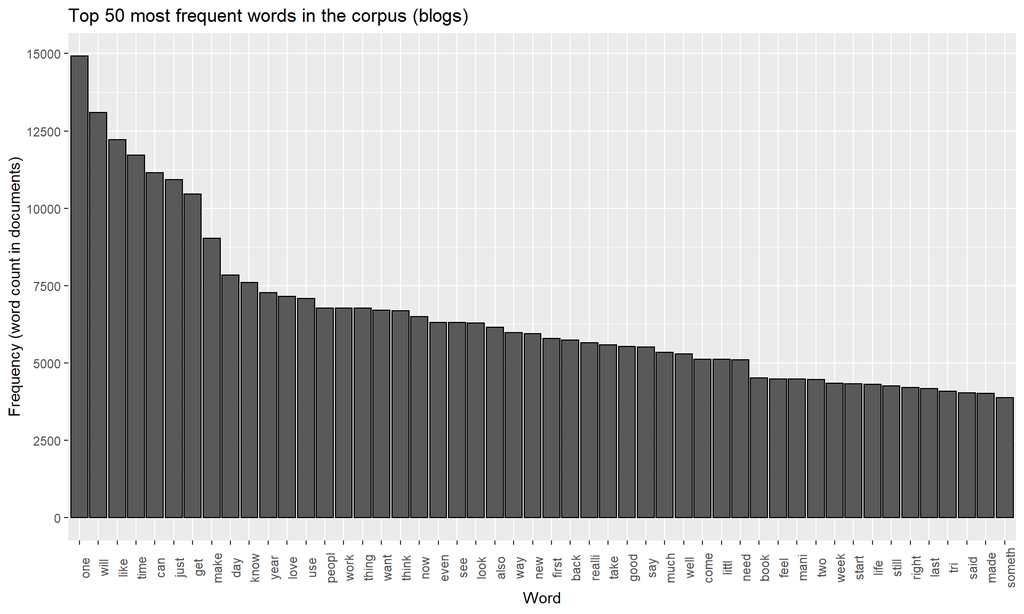

```r
blog.TFV.df.sum %>%
  filter(rank_word <= 50) %>%
  mutate(word = fct_inorder(f = word)) %>%
  ggplot(aes(x = word, y = frequency)) +
  geom_col(color = "black") +
  scale_y_continuous(breaks = seq(0,20000,2500)) +
  xlab("Word") +
  ylab("Frequency (word count in documents)") +
  ggtitle("Top 50 most frequent words in the corpus (blogs)") +
  theme(axis.text.x = element_text(angle = 90))
```

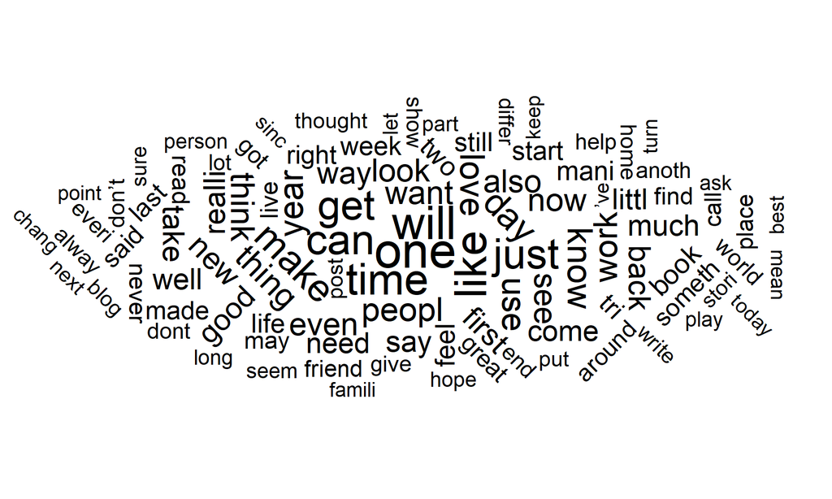

```r
set.seed(135) # randomness in positioning labels in the cloud
blog.TFV.df.sum %>%
  mutate(angle = 90 * sample(c(0,1), n(), replace = T, prob = c(0.7, 0.3))) %>%
  mutate(angle1 = 45 * sample(c(-2:2), n(), replace = T, prob = c(1,1,4,1,1))) %>%
  filter(rank_word <= 100) %>%
  ggplot(aes(label = word,
             size = frequency,
             angle = angle1)) +
  geom_text_wordcloud() +
  scale_size_area(max_size = 15) +
  theme_minimal()
```

In the blogs data the three most frequent words are: “one”, “will”, “like”.

### n-gram word frequencies

The second question is:

*“What are the frequencies of 2-grams and 3-grams in the data set?”*

Firs lets draw a distribution of word frequencies for **bi-grams** (all three corpus):

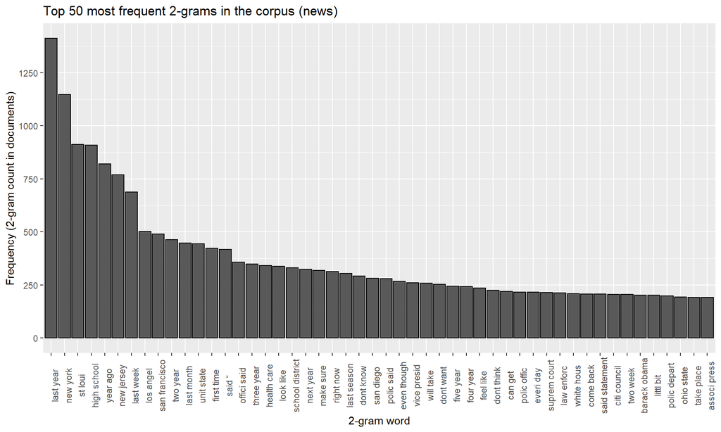

```r
# news
news.bi.Grams.df %>%
  arrange(desc(Frequency)) %>%
  head(50) %>%
  mutate(word = as.character(Word)) %>%
  mutate(word = fct_inorder(f = word)) %>%
  ggplot(aes(x = word, y = Frequency)) +
  geom_col(color = "black") +
  scale_y_continuous(breaks = seq(0,2000,250)) +
  xlab("2-gram word") +
  ylab("Frequency (2-gram count in documents)") +
  ggtitle("Top 50 most frequent 2-grams in the corpus (news)") +
  theme(axis.text.x = element_text(angle = 90))
```

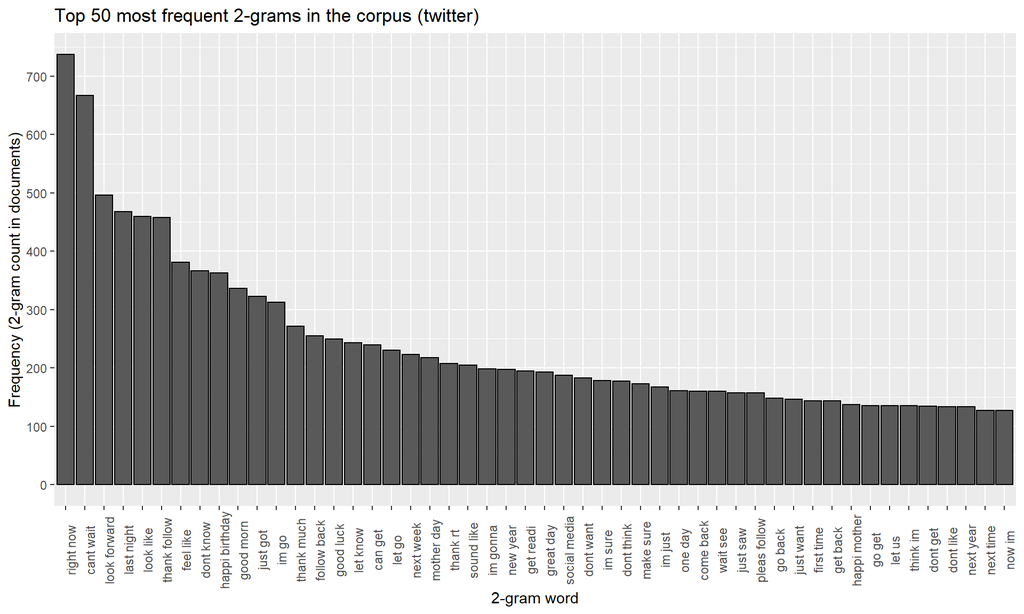

```r
twit.bi.Grams.df %>%
  arrange(desc(Frequency)) %>%
  head(50) %>%
  mutate(word = as.character(Word)) %>%
  mutate(word = fct_inorder(f = word)) %>%
  ggplot(aes(x = word, y = Frequency)) +
  geom_col(color = "black") +
  scale_y_continuous(breaks = seq(0,1000,100)) +
  xlab("2-gram word") +
  ylab("Frequency (2-gram count in documents)") +
  ggtitle("Top 50 most frequent 2-grams in the corpus (twitter)") +
  theme(axis.text.x = element_text(angle = 90))
```

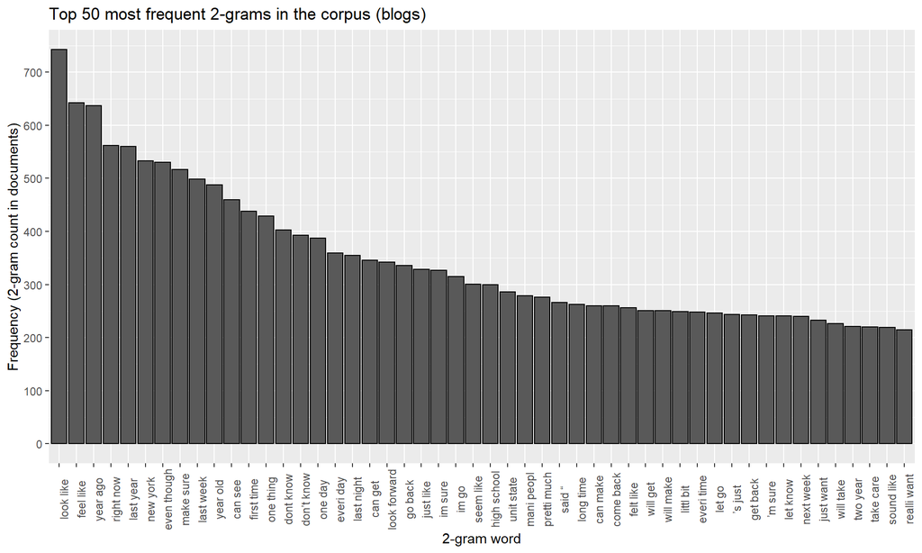

```r
# blogs
blog.bi.Grams.df %>%
  arrange(desc(Frequency)) %>%
  head(50) %>%
  mutate(word = as.character(Word)) %>%
  mutate(word = fct_inorder(f = word)) %>%
  ggplot(aes(x = word, y = Frequency)) +
  geom_col(color = "black") +
  scale_y_continuous(breaks = seq(0,1000,100)) +
  xlab("2-gram word") +
  ylab("Frequency (2-gram count in documents)") +
  ggtitle("Top 50 most frequent 2-grams in the corpus (blogs)") +
  theme(axis.text.x = element_text(angle = 90))
```

Also we can draw word cloud (only bi-gram from news drawn):

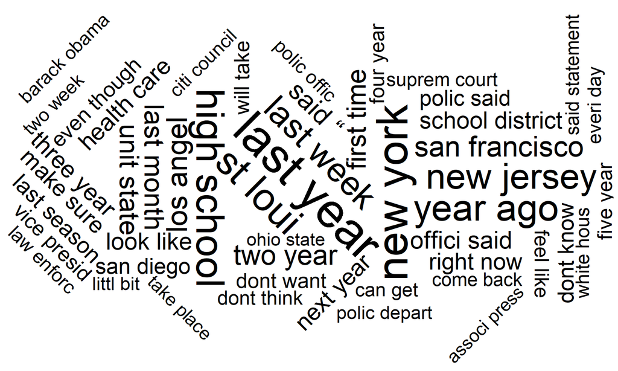

```r
set.seed(135) # randomness in positioning labels in the cloud
news.bi.Grams.df %>%
  arrange(desc(Frequency)) %>%
  head(50) %>%
  mutate(angle = 90 * sample(c(0,1), n(), replace = T, prob = c(0.7, 0.3))) %>%
  mutate(angle1 = 45 * sample(c(-2:2), n(), replace = T, prob = c(1,1,4,1,1))) %>%
  ggplot(aes(label = Word,
             size = Frequency,
             angle = angle1)) +
  geom_text_wordcloud() +
  scale_size_area(max_size = 20) +
  theme_minimal()
```

The same can be applied for three-grams:

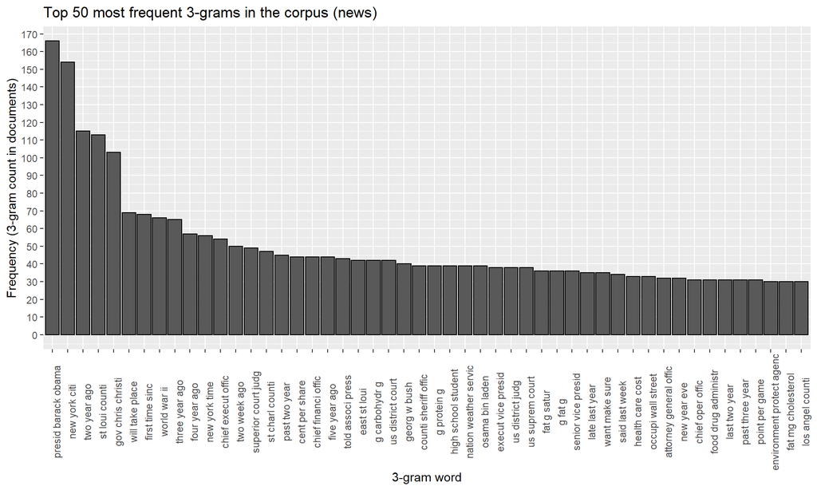

```r
# news
news.three.Grams.df %>%
  arrange(desc(Frequency)) %>%
  head(50) %>%
  mutate(word = as.character(Word)) %>%
  mutate(word = fct_inorder(f = word)) %>%
  ggplot(aes(x = word, y = Frequency)) +
  geom_col(color = "black") +
  scale_y_continuous(breaks = seq(0,1000,10)) +
  xlab("3-gram word") +
  ylab("Frequency (3-gram count in documents)") +
  ggtitle("Top 50 most frequent 3-grams in the corpus (news)") +
  theme(axis.text.x = element_text(angle = 90))
```

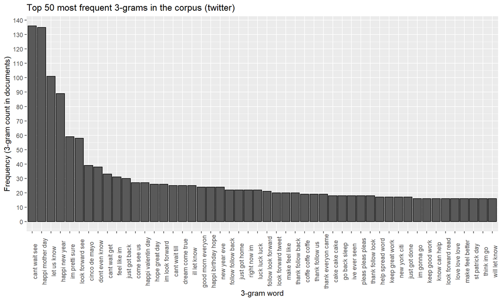

```r
# twitter
twit.three.Grams.df %>%
  arrange(desc(Frequency)) %>%
  head(50) %>%
  mutate(word = as.character(Word)) %>%
  mutate(word = fct_inorder(f = word)) %>%
  ggplot(aes(x = word, y = Frequency)) +
  geom_col(color = "black") +
  scale_y_continuous(breaks = seq(0,1000,10)) +
  xlab("3-gram word") +
  ylab("Frequency (3-gram count in documents)") +
  ggtitle("Top 50 most frequent 3-grams in the corpus (twitter)") +
  theme(axis.text.x = element_text(angle = 90))
```

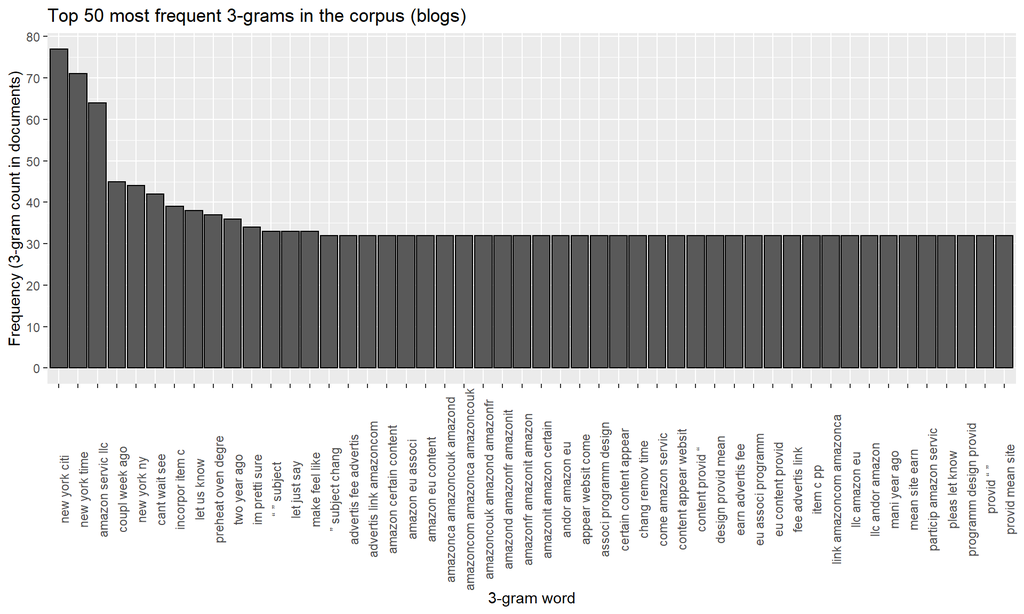

```r
# blogs
blog.three.Grams.df %>%
  arrange(desc(Frequency)) %>%
  head(50) %>%
  mutate(word = as.character(Word)) %>%
  mutate(word = fct_inorder(f = word)) %>%
  ggplot(aes(x = word, y = Frequency)) +
  geom_col(color = "black") +
  scale_y_continuous(breaks = seq(0,100,10)) +
  xlab("3-gram word") +
  ylab("Frequency (3-gram count in documents)") +
  ggtitle("Top 50 most frequent 3-grams in the corpus (blogs)") +
  theme(axis.text.x = element_text(angle = 90))
```

News three-gram word cloud:

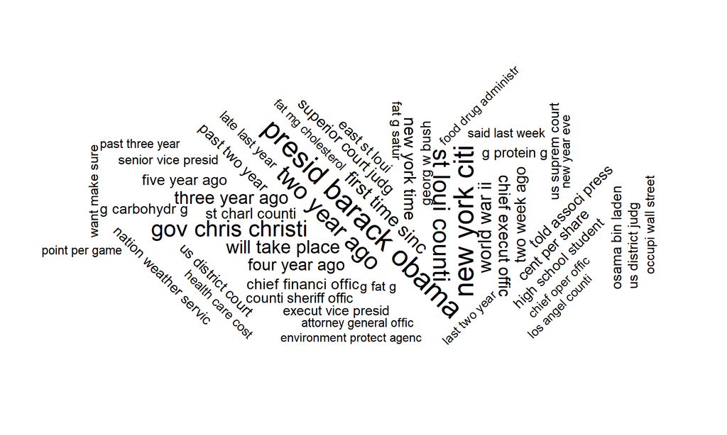

```r
set.seed(135) # randomness in positioning labels in the cloud
news.three.Grams.df %>%
  arrange(desc(Frequency)) %>%
  head(50) %>%
  mutate(angle = 90 * sample(c(0,1), n(), replace = T, prob = c(0.7, 0.3))) %>%
  mutate(angle1 = 45 * sample(c(-2:2), n(), replace = T, prob = c(1,1,4,1,1))) %>%
  ggplot(aes(label = Word,
             size = Frequency,
             angle = angle1)) +
  geom_text_wordcloud() +
  scale_size_area(max_size = 10) +
  theme_minimal()
```

An finally four-grams:

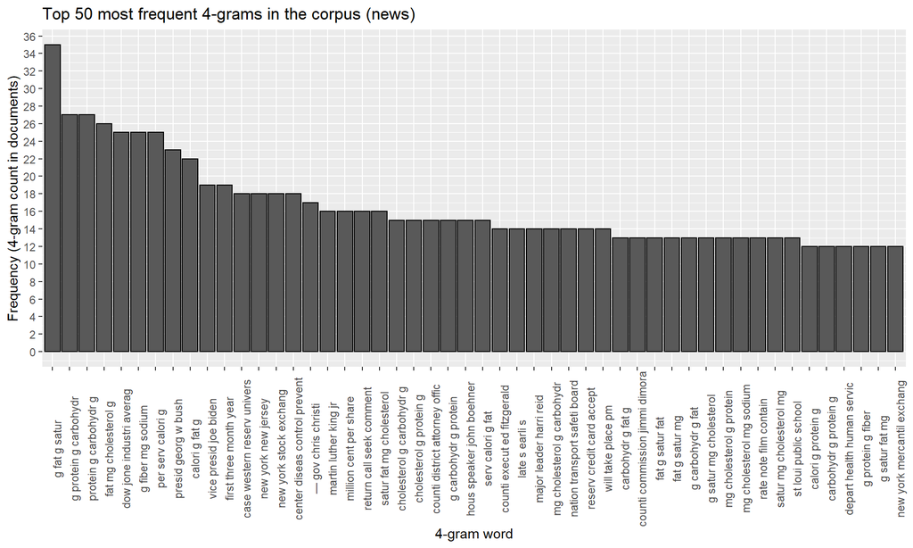

```r
# news
news.four.Grams.df %>%
  arrange(desc(Frequency)) %>%
  head(50) %>%
  mutate(word = as.character(Word)) %>%
  mutate(word = fct_inorder(f = word)) %>%
  ggplot(aes(x = word, y = Frequency)) +
  geom_col(color = "black") +
  scale_y_continuous(breaks = seq(0,100,2)) +
  xlab("4-gram word") +
  ylab("Frequency (4-gram count in documents)") +
  ggtitle("Top 50 most frequent 4-grams in the corpus (news)") +
  theme(axis.text.x = element_text(angle = 90))
```

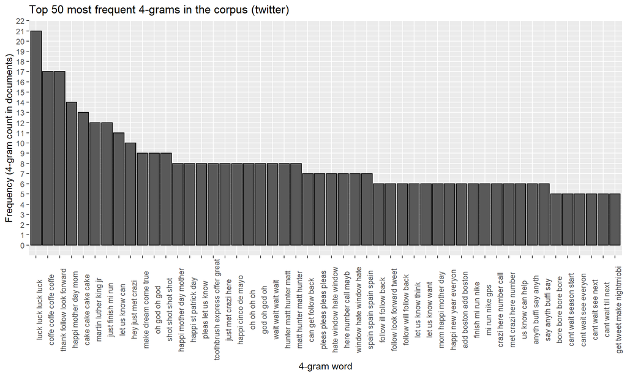

```r
# twitter
twit.four.Grams.df %>%
  arrange(desc(Frequency)) %>%
  head(50) %>%
  mutate(word = as.character(Word)) %>%
  mutate(word = fct_inorder(f = word)) %>%
  ggplot(aes(x = word, y = Frequency)) +
  geom_col(color = "black") +
  scale_y_continuous(breaks = seq(0,100,1)) +
  xlab("4-gram word") +
  ylab("Frequency (4-gram count in documents)") +
  ggtitle("Top 50 most frequent 4-grams in the corpus (twitter)") +
  theme(axis.text.x = element_text(angle = 90))
```

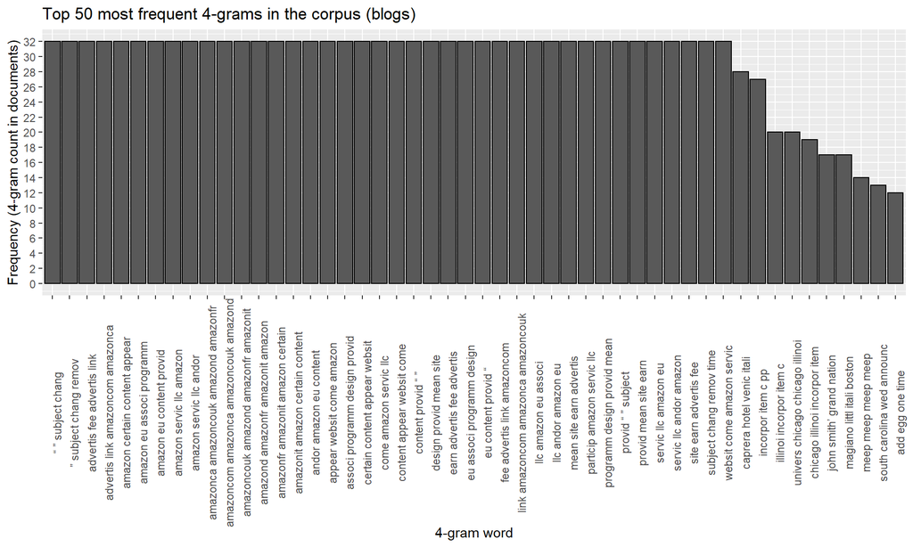

```r
# blogs
blog.four.Grams.df %>%
  arrange(desc(Frequency)) %>%
  head(50) %>%
  mutate(word = as.character(Word)) %>%
  mutate(word = fct_inorder(f = word)) %>%
  ggplot(aes(x = word, y = Frequency)) +
  geom_col(color = "black") +
  scale_y_continuous(breaks = seq(0,100,2)) +
  xlab("4-gram word") +
  ylab("Frequency (4-gram count in documents)") +
  ggtitle("Top 50 most frequent 4-grams in the corpus (blogs)") +
  theme(axis.text.x = element_text(angle = 90))
```

News four-gram word cloud:

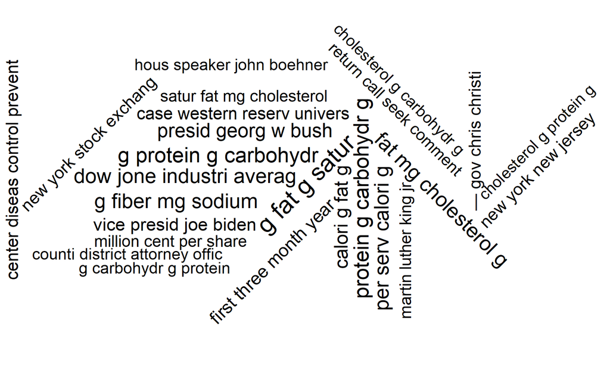

```r
set.seed(135) # randomness in positioning labels in the cloud
news.four.Grams.df %>%
  arrange(desc(Frequency)) %>%
  head(25) %>%
  mutate(angle = 90 * sample(c(0,1), n(), replace = T, prob = c(0.7, 0.3))) %>%
  mutate(angle1 = 45 * sample(c(-2:2), n(), replace = T, prob = c(1,1,4,1,1))) %>%
  ggplot(aes(label = Word,
             size = Frequency,
             angle = angle1)) +
  geom_text_wordcloud() +
  scale_size_area(max_size = 10) +
  theme_minimal()
```

### Word coverage

In the last part of data exploration we are trying to find an answer for the question:

*“How many unique words do you need in a frequency sorted dictionary to cover 50% of all word instances in the language?”*

The idea here is to observe unique words and calculate word coverage the percentage of all words in the text covered just by a smaller portion of most frequent unique words. So we have created a plot showing a count of unique words (on x-axis) and percentage of all words in the text covered (on y-axis).

So if we draw the plot for **news corpus** we get:

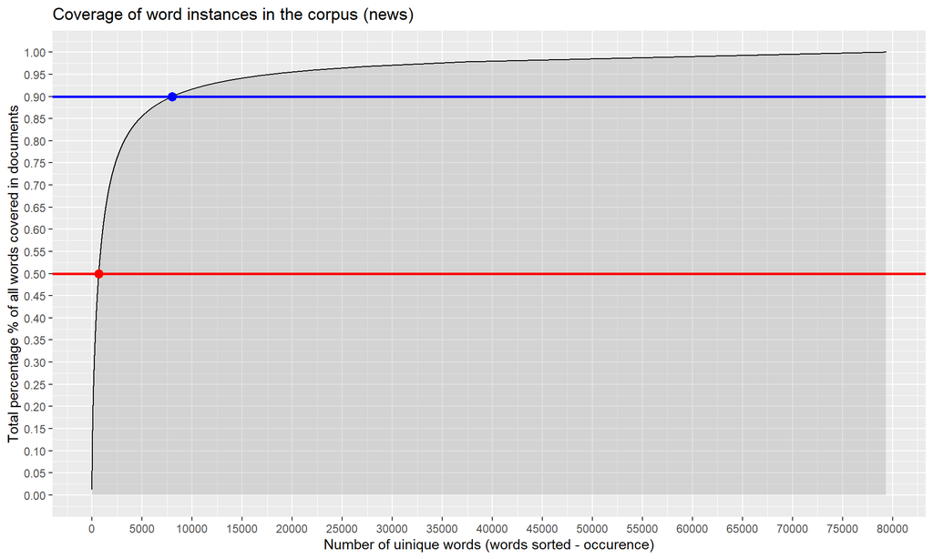

```r
news.TFV.df.sum %>%
  ggplot(aes(x = rank_word, y = percent_words_covered)) +
  geom_area(fill = "gray61", color = "black", alpha = 0.3) +
  geom_hline(yintercept = 0.5, color = "red", size = 1) +
  geom_point(data = news.TFV.df.sum %>%
               filter(percent_words_covered <= 0.5) %>%
               tail(1), aes(x = rank_word,
                            y = percent_words_covered),
             color = "red", size = 3) +
  geom_hline(yintercept = 0.9, color = "blue", size = 1) +
  geom_point(data = news.TFV.df.sum %>%
               filter(percent_words_covered <= 0.9) %>%
               tail(1), aes(x = rank_word,
                            y = percent_words_covered),
             color = "blue", size = 3) +
  scale_x_continuous(breaks = seq(0,100000,5000)) +
  scale_y_continuous(breaks = seq(0,1,0.05)) +
  xlab("Number of uinique words (words sorted - occurence)") +
  ylab("Total percentage % of all words covered in documents") +
  ggtitle("Coverage of word instances in the corpus (news)")
```

On the plot, red line marks 50% of all words covered in the text, and blue line marks 90% of all words covered in the text. Gray shaded area shows the percentage of all words covered in the text by top n-most frequent words.

We can see that around 700 top most frequent words cover 50% of all words in the text of news corpus (sampled data!).

So if we draw the plot for **twitter corpus** we get:

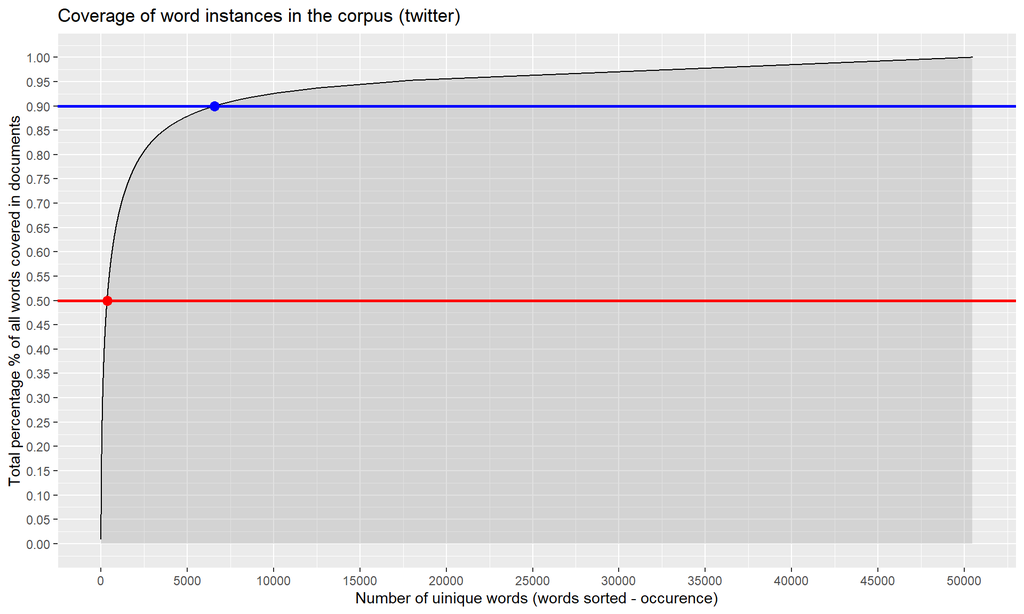

```r
twit.TFV.df.sum %>%
  ggplot(aes(x = rank_word, y = percent_words_covered)) +
  geom_area(fill = "gray61", color = "black", alpha = 0.3) +
  geom_hline(yintercept = 0.5, color = "red", size = 1) +
  geom_point(data = twit.TFV.df.sum %>%
               filter(percent_words_covered <= 0.5) %>%
               tail(1), aes(x = rank_word,
                            y = percent_words_covered),
             color = "red", size = 3) +
  geom_hline(yintercept = 0.9, color = "blue", size = 1) +
  geom_point(data = twit.TFV.df.sum %>%
               filter(percent_words_covered <= 0.9) %>%
               tail(1), aes(x = rank_word,
                            y = percent_words_covered),
             color = "blue", size = 3) +
  scale_x_continuous(breaks = c(seq(0,100000,5000))) +
  scale_y_continuous(breaks = seq(0,1,0.05)) +
  xlab("Number of uinique words (words sorted - occurence)") +
  ylab("Total percentage % of all words covered in documents") +
  ggtitle("Coverage of word instances in the corpus (twitter)")
```

We can see that around 350 top most frequent words cover 50% of all words in the text of twitter corpus (sampled data!).

And finally the plot for **blogs corpus** we get:

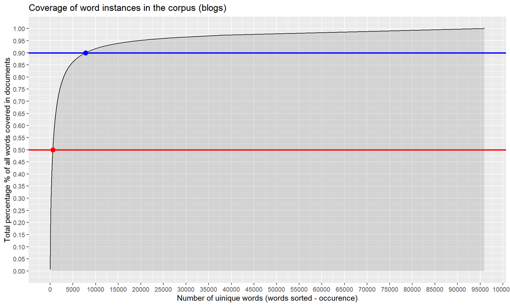

```r
blog.TFV.df.sum %>%
  ggplot(aes(x = rank_word, y = percent_words_covered)) +
  geom_area(fill = "gray61", color = "black", alpha = 0.3) +
  geom_hline(yintercept = 0.5, color = "red", size = 1) +
  geom_point(data = blog.TFV.df.sum %>%
               filter(percent_words_covered <= 0.5) %>%
               tail(1), aes(x = rank_word,
                            y = percent_words_covered),
             color = "red", size = 3) +
  geom_hline(yintercept = 0.9, color = "blue", size = 1) +
  geom_point(data = blog.TFV.df.sum %>%
               filter(percent_words_covered <= 0.9) %>%
               tail(1), aes(x = rank_word,
                            y = percent_words_covered),
             color = "blue", size = 3) +
  scale_x_continuous(breaks = seq(0,100000,5000)) +
  scale_y_continuous(breaks = seq(0,1,0.05)) +
  xlab("Number of uinique words (words sorted - occurence)") +
  ylab("Total percentage % of all words covered in documents") +
  ggtitle("Coverage of word instances in the corpus (blogs)")
```

We can see that around 600 top most frequent words cover 50% of all words in the text of blogs corpus (sampled data!).

# Model & Word prediction App

The next step and the main part of the project is to build the prediction algorithm, which will predict the next word using the sequence of words provided by the user. This prediction algorithm falls in the field of **Natural Language Processing** (**NLP**) - language modeling. Algorithm will be integrated into Shiny app, so the model can be applied via online Shiny app. We haven’t finished this final step, but we have set the path that will lead to final model.

The basic idea for the algorithm is, we would like to predict the word $w_k$, if we know the sequence of words provided by the app user ($w_1$, $w_2$, …, $w_{k-1}$). So the user can provide one word in this case $k$ is 2, or it can provide 2 words then $k$ is 3 and so on. The general prediction for the word we are looking for is:

$$p(w_k|w_{k-1}w_{k-2}...w_1)$$

Where we are predicting a probability for the word $w_k$ (word not provided by user, that is a logical next word after the sequence of words provided by user). We know the sequence of words provided by the user ($w_{k-1}w_{k-2}...w_1$), which are prior to the word we are trying to predict. We will use our corpus data and build $n$-grams in order to calculate counts for different combinations of word sequences that go with the word inputted by the user.

We will try to make the model as simple as possible, therefore we will not consider a very long sequence of prior words, but will consider only a few prior words (most recent). So our modeling will be easier in the sense of calculations complexity. And also this methodology is backed up with so called **Markov assumption** - we do not have to take the whole prior word sequence history, but we can provide only few $n-1$ past terms. So the prediction looks like this:

$$p(w_i|w_1...w_{i-1}) = p(w_i|w_{i-n+1}...w_{i-1})$$

This is easier to incorporate using real data, and we will not be too far from the truth.

For example let’s say, that the user inputs only one word, and would like to get the prediction for the next (second) word. This can be seen as a bi-gram language model:

$$p(w) = \prod_{i=1}^{k+1}p(w_i|w_{i-1})$$

So in this case we would be able to estimate probabilities using calculated bi-grams from our real data corpus by calculating conditional probabilities with word counts from the data:

$$p(w_i|w_{i-1}) = \frac{c(w_{i-1}w_i)}{\sum_{w_i}c(w_{i-1}w_i)}$$
Where $c()$ stands for counting word frequencies and $w_{i-1}w_i$ is a bi-gram word sequence, where $w_i$ is the word we are predicting (from the corpus), and $w_{i-1}$ is a word provided by the user of the app (we will try to find in bi-grams).

Here we will be able to use bi-grams, three-grams and so on. But there are still some aspects needed to be considered:

- what to do with the words not seen in the corpus data?
- what is the optimal size for n-gram tables used in the prediction (we will run the model on Shiny servers)?
- how to “smooth” the word probabilities?
- how to integrate a so called **backoff model** for estimating the probabilities of unobserved n-grams?
- how to integrate the model with the Shiny app?